# MATH 140: Scatter plots and Linear Regression

Hitchman

# The planets data

The following code creates a data frame with 3 variables (named *planet*, *distance*, and *period*) and 9 observations. This data frame encodes information about the 9 planets in the solar system.

```r
planets = data.frame(
  planet=c("Mercury","Venus","Earth","Mars","Jupiter","Saturn","Uranus","Neptune","Pluto"),
  distance=c(36,67,93,142,484,887,1765,2791,3654),
  period=c(88, 225, 365, 687, 4332, 10760, 30684, 60188, 90467)
  )
```

Notes about this code:

- `planets` is the name of the data frame
- `data.frame()` is the command for creating a data frame
- the data frame has three columns named `planet`, `distance`, and `period`
- the column entries are created with the `c()` command.
- the entries for a categorical variable such as the *planet* variable are enclosed, individually, with quotes.
- the units:
  - `distance` is given in millions of miles from the Sun
  - `period` is given in Earth days (how long it takes the planet to make one revolution around the Sun)

# Making a scatter plot

We can make quick and clear scatter plots using the built-in R command `plot()`, or higher quality plots using the package `ggplot`.

## Using `plot()`

In the worksheet we choose `distance` to be the explanatory variable ($x$), and `period` to be the response variable ($y$). The `plot()` command produces a scatter plot:

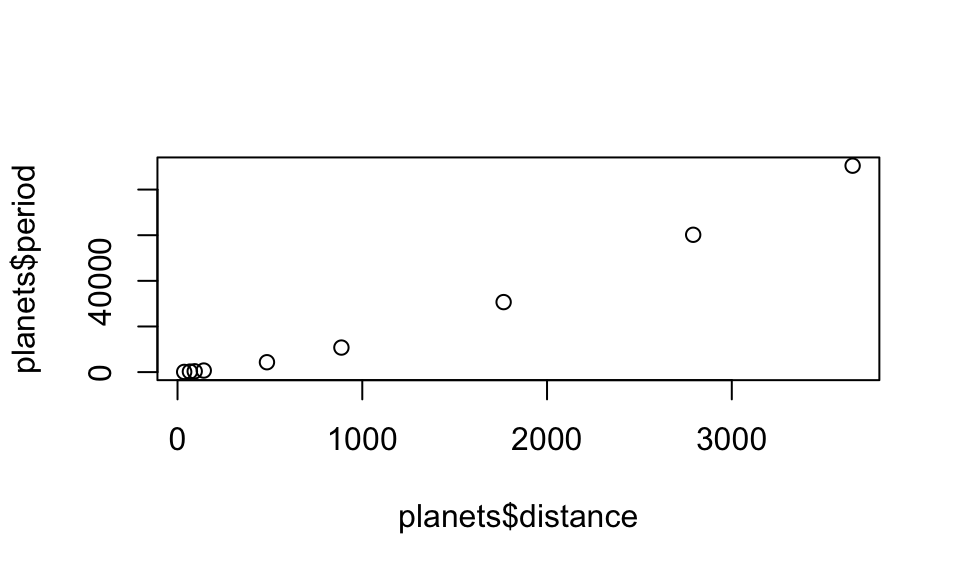

```r
plot(x=planets$distance,y=planets$period)
```

But we should make our graphs more user friendly by adding a plot title and better axis labels:

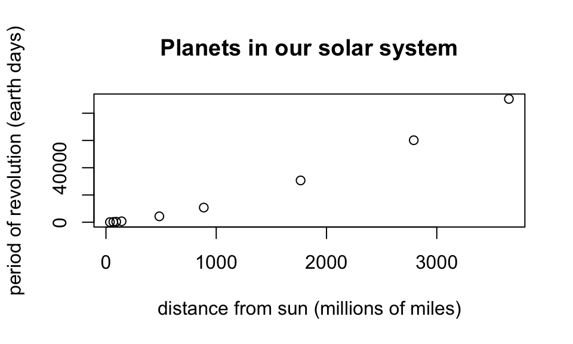

```r
plot(x=planets$distance,y=planets$period,
     xlab="distance from sun (millions of miles)",
     ylab="period of revolution (earth days)",
     main="Planets in our solar system")
```

We can even change the look of the points, as discussed in the [Getting Started in R Studio tutorial](https://mphitchman.com/stats/Rlabs/getting-started.html#Scatter_plots)

## Using `ggplot()`

The *tidyverse* package (which you’ve already installed) comes with an excellent graphics package called *ggplot*. If you load the tidyverse into your RStudio session, you will be able to produce graphics with *ggplot*.

To load the tidyverse into your session, run this line:

```
library(tidyverse)
```

With the tidyverse loaded, you are ready to use the ggplot functions for generating graphs.

**Basic scatter plot with ggplot**

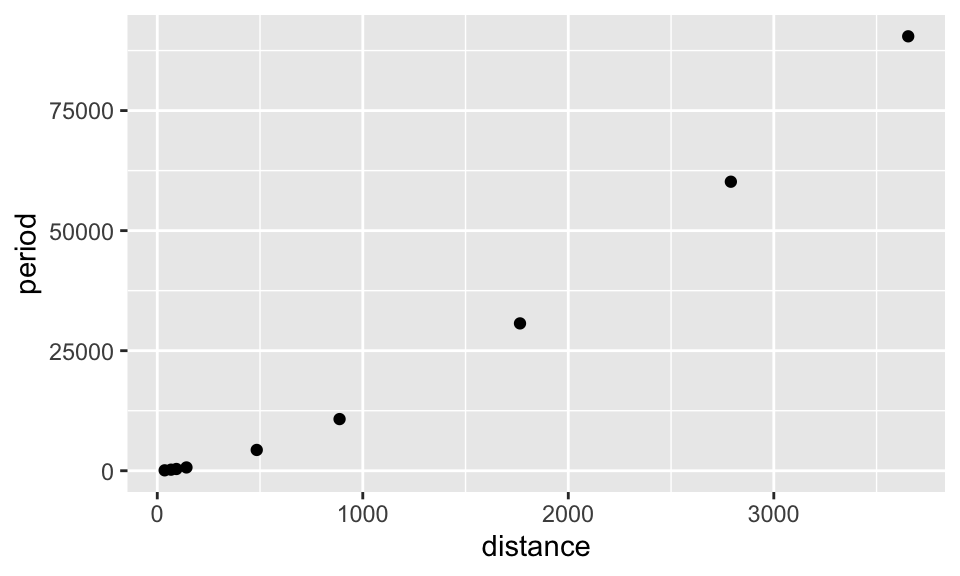

```r
ggplot(data = planets,aes(x=distance,y=period)) +
  geom_point()
```

**Adding color, labels, and changing themes.**

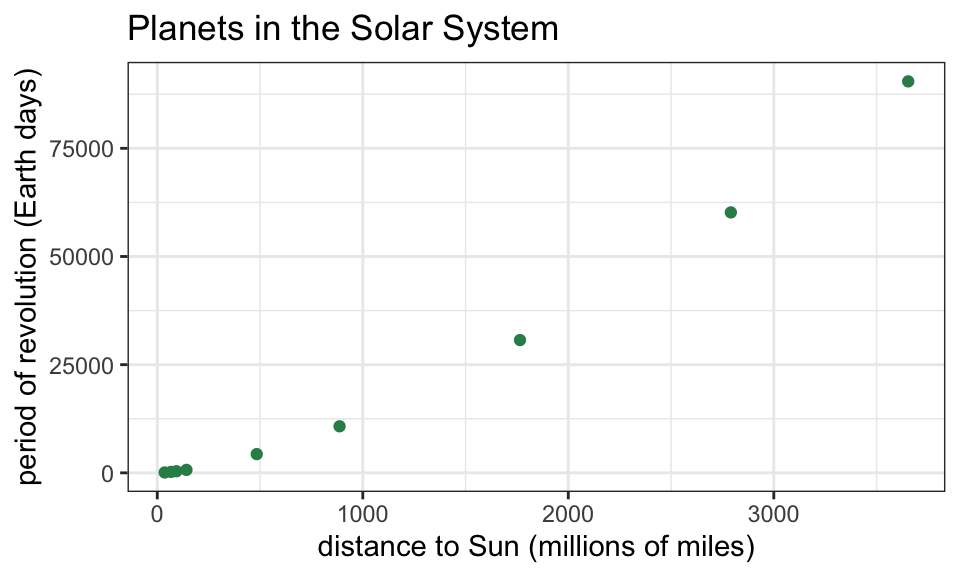

```r
ggplot(data = planets,aes(x=distance,y=period)) +
  geom_point(col="seagreen")+
  xlab("distance to Sun (millions of miles)") +
  ylab("period of revolution (Earth days)") +
  ggtitle("Planets in the Solar System") +
  theme_bw()
```

## The correlation coefficient

We use the `cor()` command:

```r
cor(planets$distance,planets$period)
```

```
## [1] 0.9889708
```

# The least-squares linear model

> Use the `lm()` command (“lm” stands for linear model). Running `lm(y~x)` where y and x are specified columns in your data frame will give the slope and $y$-intercept of the least-squares regression line:

```r
lm(planets$period~planets$distance)
```

```
##
## Call:
## lm(formula = planets$period ~ planets$distance)
##
## Coefficients:
##      (Intercept)  planets$distance
##          -4578.8              24.1
```

So, the slope of the least-squares line is 24.1 and the $y$-intercept is -4578.8.

Better yet, assign a name to the `lm()` command, like *fit*, when you run it (as in the code below) and you have quick access to all sorts of useful information:

```r
fit=lm(planets$period~planets$distance)
```

| Command | Result |
| --- | --- |
| `fit$coefficients` | $y$-intercept and slope of least-squares line |
| `fit$residuals` | list of the residuals |
| `fit$fitted.values` | list of the predicted values $\hat{y}$ |

# Plot the least-squares line

## Using built-in R commands

RStudio likes to describe the $y$-intercept and slope of a line with the constants $a$ and $b$, respectively. As in
$$y=a + bx,$$
and the command `abline(a= ..., b=...)` will add a line with $y$-intercept $a$ and slope $b$ to a plot if you run these lines of code in succession:

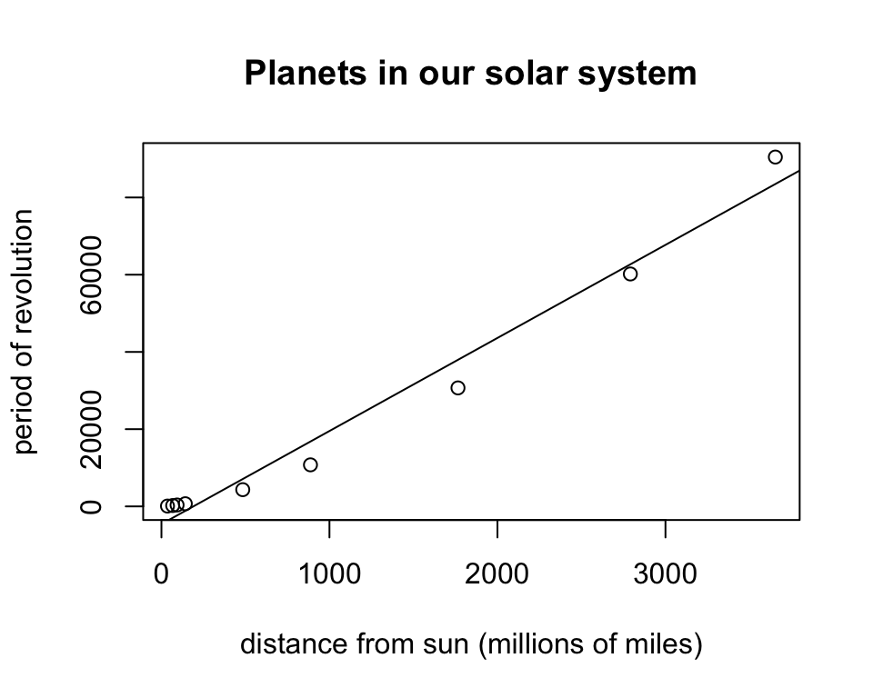

```r
plot(x=planets$distance,y=planets$period,
     xlab="distance from sun (millions of miles)",
     ylab="period of revolution",
     main="Planets in our solar system")
abline(a=-4578.8,b=24.1)
```

## Making a Residual Plot

We can plot the $x$-coordinates against the residuals and add a dashed horizontal line through $y = 0$ with this code

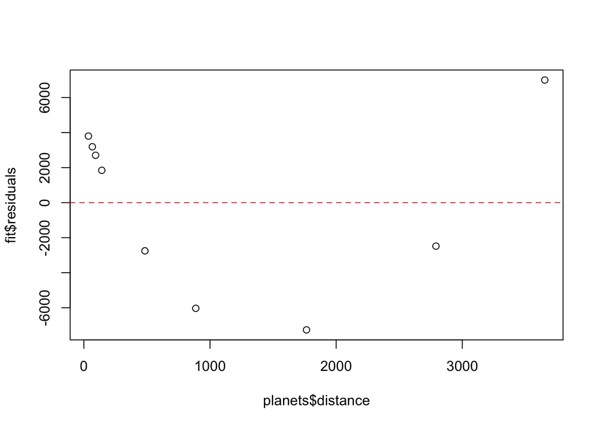

```r
plot(planets$distance,fit$residuals)
abline(h=0,lty=2,col="brown3")
```

## In ggplot

### With the `geom_abline()` command

Here are two approaches. The first adds the line with the `geom_abline()` command by manually entering the slope and y-intercept as found above:

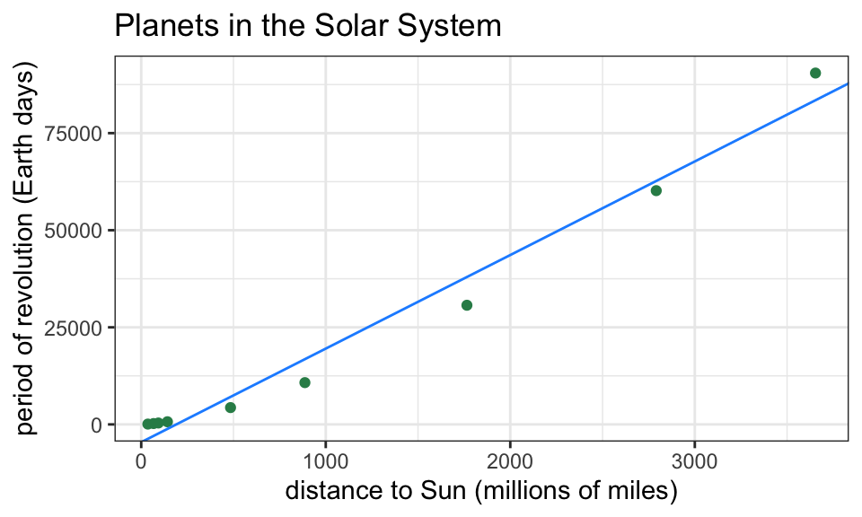

```r
ggplot(data = planets,aes(x=distance,y=period)) +
  geom_point(col="seagreen") +
  xlab("distance to Sun (millions of miles)") +
  ylab("period of revolution (Earth days)") +
  ggtitle("Planets in the Solar System") +
  geom_abline(slope = 24.1, intercept = -4578.8,col="dodgerblue")+
  theme_bw()
```

### Using geom_smooth()

The second approach to fitting a line to data is to use the `geom_smooth()`command. The advantage here is that the code generates the line from scratch - you don’t have to manually enter the slope and $y$-intercept.

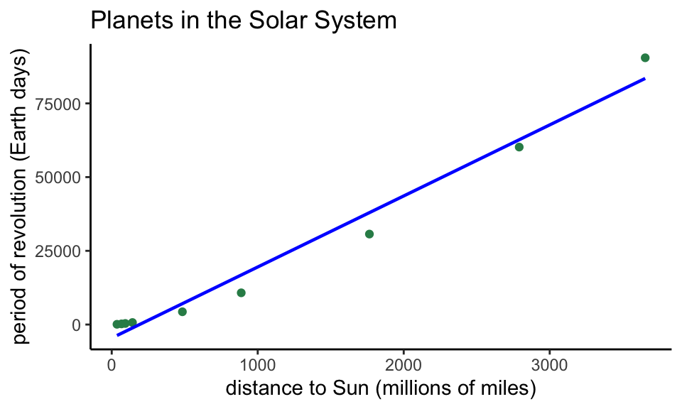

```r
ggplot(data = planets,aes(x=distance,y=period)) +
  geom_point(col="seagreen")+
  xlab("distance to Sun (millions of miles)") +
  ylab("period of revolution (Earth days)") +
  ggtitle("Planets in the Solar System") +
  geom_smooth(method='lm', formula=y~x, col="blue",size=.8,se=FALSE) +
  theme_classic()
```

Notice the new “classic” theme!

# Bonus Round: A Better Model

The residual plot makes clear that, even though the correlation coefficient is very close to 1, a curved model is better, one that can be represented by a polynomial with a higher power of $x$.

To find the nature of the curved fit, we begin by comparing `log(x)` to `log(y)`.

**Intermission: Logarithms**

Recall, $\log_{10}(x)$ = the power we need to raise 10 to in order to get $x$. For instance, $\log_{10}(100) = 2$ since 10^2 = 100$, $\log_{10}(1000) = 3$, $\log_10(1,000,000) = 6$, and $\log_{10}(0.1)=-1$ since $10^{-1} = \frac{1}{10}=0.1$.

**End of Intermission**

So, again, to find the nature of the curved fit, we begin by comparing `log(x)` to `log(y)`, and see whether the association is linear.

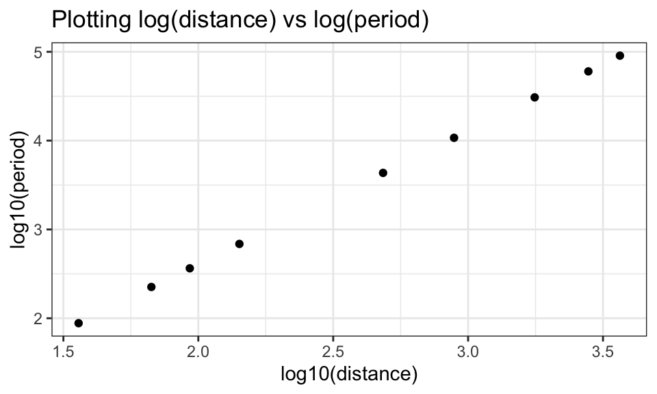

```r
ggplot(data=planets,aes(log10(distance),log10(period)))+
  geom_point()+
  ggtitle("Plotting log(distance) vs log(period)")+
  theme_bw()
```

Does this plot look linear?

*Heck yeah!* Super linear, in fact.

If the log-log plot is linear, then the slope of the least-squares line for the log-log data will equal the power in the curved fit for $y$ and $x$.

```r
logfit=lm(log10(planets$period)~log10(planets$distance))
logfit$coefficients
```

```
##             (Intercept) log10(planets$distance)
##              -0.3922215               1.5013054
```

Notice the slope of this linear model is about 1.5, and this explains why we chose the $x^{1.5}$ for the curved fit in the last question of the R Regression activity.